# Data Science Projekt

Sarolta Marton

2017 március 104308

The dataset used for the project is from and describes the properties of used cars advertised on E-bay in Germany. My aim is to predict the price of used cars, baed on the most important variables. Access to the dataset:

https://www.kaggle.com/orgesleka/used-cars-database

Over 370000 used cars scraped with Scrapy from Ebay-Kleinanzeigen. The content of the data is in german, so one has to translate it first if one can not speak german. Those fields are included: autos.csv:

Original variables:

dateCrawled : when this ad was first crawled, all field-values are taken from this date name : “name” of the car seller : private or dealer offerType price : the price on the ad to sell the car abtest vehicleType yearOfRegistration : at which year the car was first registered gearbox powerPS : power of the car in PS model kilometer : how many kilometers the car has driven monthOfRegistration : at which month the car was first registered fuelType brand notRepairedDamage : if the car has a damage which is not repaired yet dateCreated : the date for which the ad at ebay was created nrOfPictures : number of pictures in the ad (unfortunately this field contains everywhere a 0 and is thus useless (bug in crawler!) ) postalCode lastSeenOnline : when the crawler saw this ad last online

[output not shown]

Summary of our data:

```r
summary(data)
```

```
##            brand           price            vehicleType
##  volkswagen   :26464   Min.   :   100   limousine :37665
##  bmw          :15127   1st Qu.:  1700   kleinwagen:27336
##  mercedes_benz:13128   Median :  4000   kombi     :26343
##  opel         :12392   Mean   :  7095   bus       :12473
##  audi         :12325   3rd Qu.:  8999   cabrio    : 9361
##  ford         : 8384   Max.   :849000   coupe     : 7335
##  (Other)      :39593                    (Other)   : 6900
##  yearOfRegistration      gearbox         powerPS         kilometer
##  Min.   :1934       automatik:30272   Min.   :  50.0   Min.   :  5000
##  1st Qu.:2000       manuell  :97141   1st Qu.:  88.0   1st Qu.:100000
##  Median :2004                         Median : 118.0   Median :150000
##  Mean   :2004                         Mean   : 131.2   Mean   :123655
##  3rd Qu.:2008                         3rd Qu.: 160.0   3rd Qu.:150000
##  Max.   :2018                         Max.   :1000.0   Max.   :150000
##
##     fuelType     notRepairedDamage
##  andere :   25   ja  : 12520
##  benzin :81885   nein:114893
##  cng    :  235
##  diesel :43149
##  elektro:   11
##  hybrid :  117
##  lpg    : 1991
```

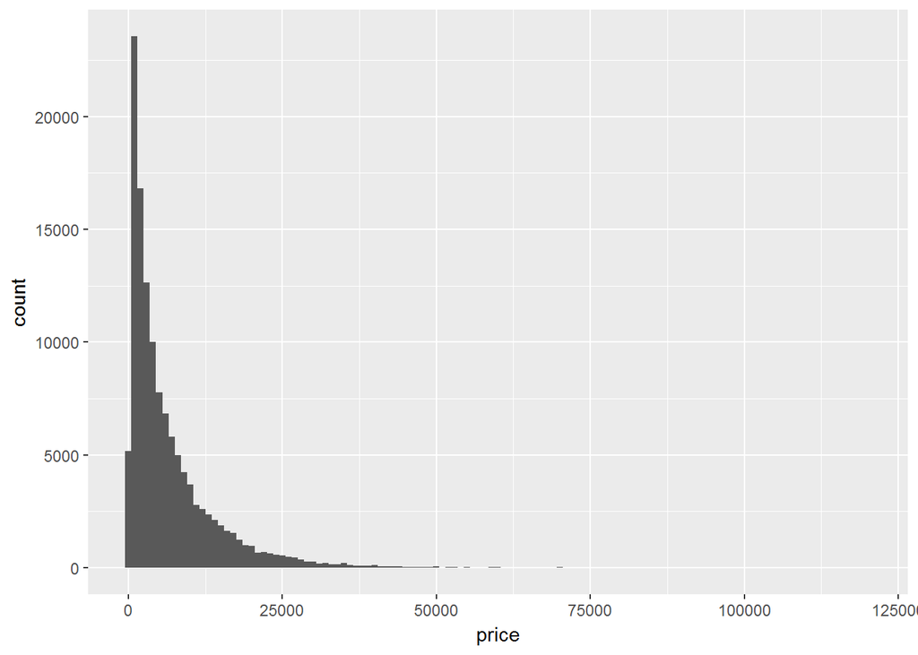

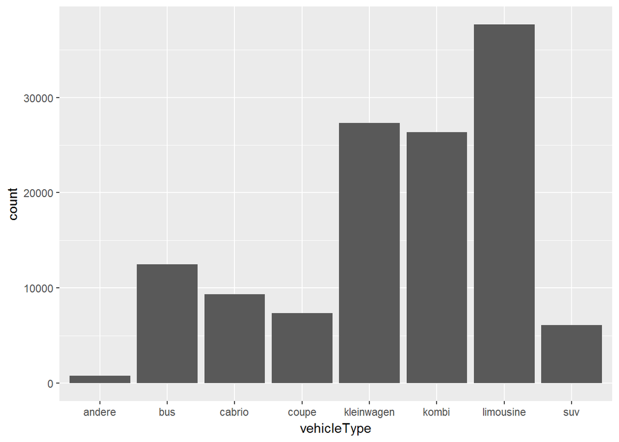

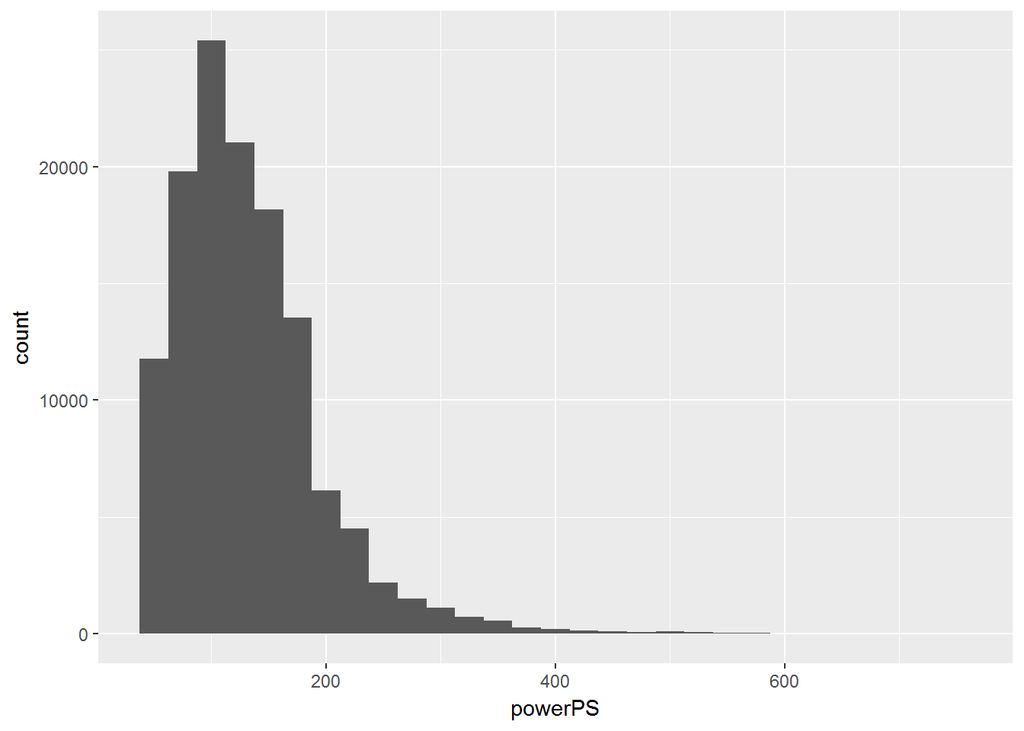

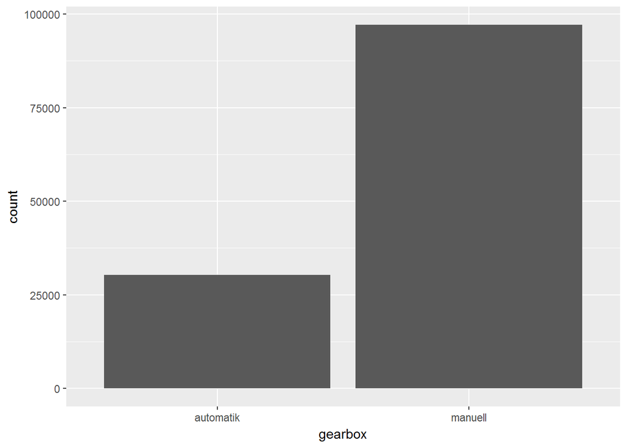

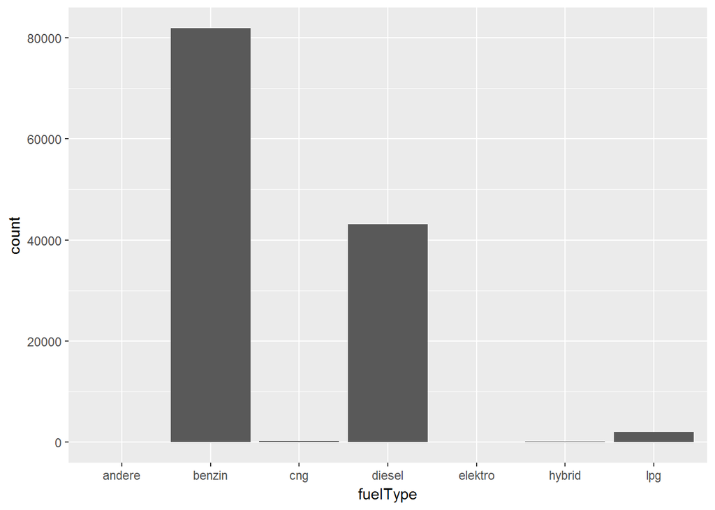

Descriptive Statistic:

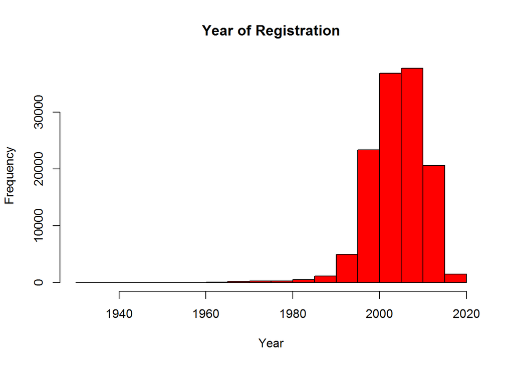

```r
hist(data$yearOfRegistration, right = FALSE,  col = "red", main = "Year of Registration", xlab = "Year")
```

Part II Machine learning part.

```r
df<-data
set.seed(1234)
N1<-nrow(df)
vt<-sample(1:N1,0.6*N1)
d_train<-df[vt,]
d_vt<-df[-vt,]
N2<-nrow(d_vt)
t<-sample(1:N2,0.5*N2)
d_valid<-d_vt[t,]
d_test<-d_vt[-t,]

colnames(d_test)
```

```
## [1] "brand"              "price"              "vehicleType"
## [4] "yearOfRegistration" "gearbox"            "powerPS"
## [7] "kilometer"          "fuelType"           "notRepairedDamage"
```

Plot of Linear model:

Blue dots show manuell gearbox and the red ones show automatik gearbox. We can observe, that automatik gearboxes started to be more trendy after the 1990s.

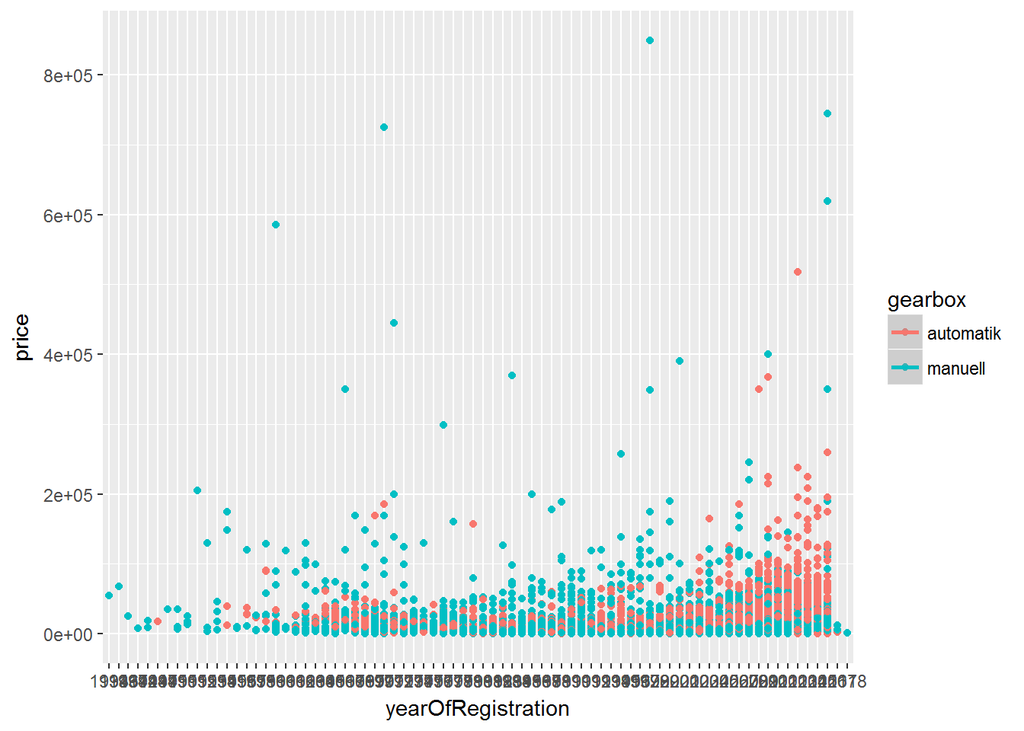

```r
ggplot(data, aes(yearOfRegistration, price, color=gearbox))+ geom_point()+ geom_smooth(method = 'lm', se= TRUE)
```

Summary of the Linear model.

Price~yearOfRegistration

```r
lmm<-(lm(data=d_train,price~yearOfRegistration))
summary(lmm)
```

```
##
## Call:
## lm(formula = price ~ yearOfRegistration, data = d_train)
##
## Residuals:
##    Min     1Q Median     3Q    Max
## -82056  -2380   -981    911 846764
##
## Coefficients:
##                        Estimate Std. Error t value Pr(>|t|)
## (Intercept)               55000       9122   6.029 1.66e-09 ***
## yearOfRegistration1936    13000      12901   1.008 0.313621
## yearOfRegistration1943   -41300      11173  -3.696 0.000219 ***
## yearOfRegistration1947   -36750      12901  -2.849 0.004393 **
## yearOfRegistration1949   -20000      12901  -1.550 0.121087
## yearOfRegistration1950   -48500      12901  -3.759 0.000170 ***
## yearOfRegistration1951   -33300      11173  -2.980 0.002879 **
## yearOfRegistration1952   150000      12901  11.627  < 2e-16 ***
## yearOfRegistration1953    14500      11173   1.298 0.194360
## yearOfRegistration1954   -29675      10199  -2.910 0.003621 **
## yearOfRegistration1955    39450      11173   3.531 0.000414 ***
## yearOfRegistration1956   -46256      11173  -4.140 3.48e-05 ***
## yearOfRegistration1957    -1552      10534  -0.147 0.882868
## yearOfRegistration1958   -49501      11173  -4.430 9.42e-06 ***
## yearOfRegistration1959    -7861      10199  -0.771 0.440849
## yearOfRegistration1960    29516       9568   3.085 0.002037 **
## yearOfRegistration1961   -46500      11173  -4.162 3.16e-05 ***
## yearOfRegistration1962   -30834       9853  -3.129 0.001753 **
## yearOfRegistration1963   -20089       9467  -2.122 0.033843 *
## yearOfRegistration1964   -29593       9467  -3.126 0.001773 **
## yearOfRegistration1965   -29189       9387  -3.110 0.001875 **
## yearOfRegistration1966   -34383       9328  -3.686 0.000228 ***
## yearOfRegistration1967   -28502       9337  -3.053 0.002270 **
## yearOfRegistration1968   -32986       9328  -3.536 0.000406 ***
## yearOfRegistration1969   -35260       9311  -3.787 0.000153 ***
## yearOfRegistration1970   -39444       9337  -4.224 2.40e-05 ***
## yearOfRegistration1971    -1310       9311  -0.141 0.888065
## yearOfRegistration1972   -22945       9245  -2.482 0.013071 *
## yearOfRegistration1973   -43806       9252  -4.735 2.20e-06 ***
## yearOfRegistration1974   -41093       9245  -4.445 8.81e-06 ***
```

[output cut: 34 more lines]

```
## yearOfRegistration2009   -44798       9124  -4.910 9.12e-07 ***
## yearOfRegistration2010   -41797       9124  -4.581 4.63e-06 ***
## yearOfRegistration2011   -39977       9124  -4.382 1.18e-05 ***
## yearOfRegistration2012   -38641       9124  -4.235 2.29e-05 ***
## yearOfRegistration2013   -35953       9125  -3.940 8.16e-05 ***
## yearOfRegistration2014   -32293       9126  -3.539 0.000402 ***
## yearOfRegistration2015   -27967       9128  -3.064 0.002186 **
## yearOfRegistration2016   -14448       9168  -1.576 0.115074
## yearOfRegistration2018   -53100      12901  -4.116 3.86e-05 ***
## ---
## Signif. codes:  0 '***' 0.001 '**' 0.01 '*' 0.05 '.' 0.1 ' ' 1
##
## Residual standard error: 9123 on 76374 degrees of freedom
## Multiple R-squared:  0.2957, Adjusted R-squared:  0.295
## F-statistic: 445.3 on 72 and 76374 DF,  p-value: < 2.2e-16
```

```r
lmb<-(lm(data=d_train,price~brand))
summary(lmb)
```

```
##
## Call:
## lm(formula = price ~ brand, data = d_train)
##
## Residuals:
##    Min     1Q Median     3Q    Max
## -44428  -4187  -1837   2025 842467
##
## Coefficients:
##                      Estimate Std. Error t value Pr(>|t|)
## (Intercept)          5177.343    444.595  11.645  < 2e-16 ***
## brandaudi            5047.606    459.506  10.985  < 2e-16 ***
## brandbmw             4341.325    456.736   9.505  < 2e-16 ***
## brandchevrolet       1341.904    669.780   2.003 0.045127 *
## brandchrysler         -69.412    722.614  -0.096 0.923476
## brandcitroen         -827.683    541.293  -1.529 0.126248
## branddacia           1089.224    822.571   1.324 0.185450
## branddaewoo         -3991.393   1092.656  -3.653 0.000259 ***
## branddaihatsu       -3056.473    956.232  -3.196 0.001392 **
## brandfiat           -1701.076    503.808  -3.376 0.000735 ***
## brandford            -745.622    466.376  -1.599 0.109878
## brandhonda           -393.701    606.838  -0.649 0.516486
## brandhyundai         1089.271    565.334   1.927 0.054012 .
## brandjaguar         10031.629    943.129  10.637  < 2e-16 ***
## brandjeep            7152.348    870.256   8.219  < 2e-16 ***
## brandkia             1238.184    610.532   2.028 0.042560 *
## brandlada           -1538.374   1793.474  -0.858 0.391027
## brandlancia         -1185.887   1131.603  -1.048 0.294656
## brandland_rover     13663.284    858.003  15.925  < 2e-16 ***
## brandmazda           -487.145    528.321  -0.922 0.356499
## brandmercedes_benz   4365.420    458.649   9.518  < 2e-16 ***
## brandmini            5387.216    560.764   9.607  < 2e-16 ***
## brandmitsubishi     -1184.864    608.787  -1.946 0.051626 .
## brandnissan           585.900    544.787   1.075 0.282170
## brandopel           -1550.032    459.496  -3.373 0.000743 ***
## brandpeugeot        -1344.703    490.291  -2.743 0.006096 **
## brandporsche        40200.932    617.909  65.060  < 2e-16 ***
## brandrenault        -2224.269    478.257  -4.651 3.31e-06 ***
## brandrover          -2585.449   1116.392  -2.316 0.020567 *
## brandsaab            -996.618   1054.343  -0.945 0.344534
## brandseat               9.088    516.203   0.018 0.985953
## brandskoda           2145.970    518.679   4.137 3.52e-05 ***
## brandsmart           -756.058    561.255  -1.347 0.177957
## brandsonstige_autos 15857.051    616.543  25.719  < 2e-16 ***
## brandsubaru           680.325    893.199   0.762 0.446258
## brandsuzuki          -556.106    637.932  -0.872 0.383357
## brandtoyota           771.410    535.811   1.440 0.149955
## brandvolkswagen      1355.429    451.592   3.001 0.002688 **
## brandvolvo            895.083    569.149   1.573 0.115800
## ---
## Signif. codes:  0 '***' 0.001 '**' 0.01 '*' 0.05 '.' 0.1 ' ' 1
##
## Residual standard error: 9981 on 76408 degrees of freedom
## Multiple R-squared:  0.1565, Adjusted R-squared:  0.1561
## F-statistic:   373 on 38 and 76408 DF,  p-value: < 2.2e-16
```

As we are using more variables to predict the price, the R-Squared will be higher, but still not enough high.

```r
lm<-(lm(data=d_train,price~.))
summary(lm)
```

```
##
## Call:
## lm(formula = price ~ ., data = d_train)
##
## Residuals:
##    Min     1Q Median     3Q    Max
## -78101  -1840     29   1683 849465
##
## Coefficients:
##                          Estimate Std. Error t value Pr(>|t|)
## (Intercept)             3.570e+04  7.715e+03   4.627 3.72e-06 ***
## brandaudi               2.676e+03  3.457e+02   7.742 9.92e-15 ***
## brandbmw                2.133e+03  3.435e+02   6.208 5.39e-10 ***
## brandchevrolet         -1.853e+03  5.061e+02  -3.661 0.000252 ***
## brandchrysler          -1.063e+03  5.440e+02  -1.954 0.050713 .
## brandcitroen            4.619e+02  4.084e+02   1.131 0.258045
## branddacia             -2.022e+03  6.207e+02  -3.258 0.001124 **
## branddaewoo             1.697e+03  8.194e+02   2.071 0.038367 *
## branddaihatsu           2.164e+03  7.187e+02   3.011 0.002609 **
## brandfiat               7.453e+02  3.809e+02   1.957 0.050363 .
## brandford               8.907e+02  3.510e+02   2.537 0.011168 *
## brandhonda              1.317e+03  4.561e+02   2.889 0.003869 **
## brandhyundai           -6.990e+02  4.273e+02  -1.636 0.101877
## brandjaguar             2.372e+03  7.116e+02   3.332 0.000861 ***
## brandjeep               2.304e+03  6.683e+02   3.448 0.000565 ***
## brandkia               -5.282e+02  4.604e+02  -1.147 0.251264
## brandlada              -6.738e+02  1.350e+03  -0.499 0.617698
## brandlancia             8.128e+02  8.489e+02   0.957 0.338351
## brandland_rover         8.399e+03  6.584e+02  12.756  < 2e-16 ***
## brandmazda              9.183e+02  3.969e+02   2.314 0.020681 *
## brandmercedes_benz      2.474e+03  3.460e+02   7.151 8.68e-13 ***
## brandmini               1.814e+03  4.235e+02   4.285 1.83e-05 ***
## brandmitsubishi         1.082e+03  4.576e+02   2.364 0.018082 *
## brandnissan             1.544e+03  4.102e+02   3.763 0.000168 ***
## brandopel               1.168e+03  3.460e+02   3.376 0.000736 ***
## brandpeugeot            4.772e+02  3.694e+02   1.292 0.196473
## brandporsche            2.601e+04  4.743e+02  54.832  < 2e-16 ***
## brandrenault            9.683e+02  3.612e+02   2.681 0.007344 **
## brandrover              1.532e+03  8.365e+02   1.831 0.067034 .
## brandsaab              -1.207e+02  7.900e+02  -0.153 0.878538
```

[output cut: 89 more lines]

```
## powerPS                 6.310e+01  6.438e-01  98.024  < 2e-16 ***
## kilometer              -3.433e-02  1.007e-03 -34.084  < 2e-16 ***
## fuelTypebenzin          6.211e+02  1.873e+03   0.332 0.740212
## fuelTypecng             3.655e+02  1.976e+03   0.185 0.853245
## fuelTypediesel          2.122e+03  1.874e+03   1.133 0.257407
## fuelTypeelektro        -5.812e+02  3.015e+03  -0.193 0.847159
## fuelTypehybrid          2.169e+03  2.096e+03   1.035 0.300711
## fuelTypelpg            -6.983e+02  1.885e+03  -0.370 0.711065
## notRepairedDamagenein   1.512e+03  9.246e+01  16.352  < 2e-16 ***
## ---
## Signif. codes:  0 '***' 0.001 '**' 0.01 '*' 0.05 '.' 0.1 ' ' 1
##
## Residual standard error: 7467 on 76319 degrees of freedom
## Multiple R-squared:  0.5284, Adjusted R-squared:  0.5276
## F-statistic: 673.3 on 127 and 76319 DF,  p-value: < 2.2e-16
```

For the following machine learning I used H2O

```r
stargazer(lm(data=d_train,price~brand))
```

[output not shown]

[output cut: 86 more lines]

```
##   & \\
##  Constant & 5,177.343$^{***}$ \\
##   & (444.595) \\
##   & \\
## \hline \\[-1.8ex]
## Observations & 76,447 \\
## R$^{2}$ & 0.156 \\
## Adjusted R$^{2}$ & 0.156 \\
## Residual Std. Error & 9,981.143 (df = 76408) \\
## F Statistic & 373.023$^{***}$ (df = 38; 76408) \\
## \hline
## \hline \\[-1.8ex]
## \textit{Note:}  & \multicolumn{1}{r}{$^{*}$p$<$0.1; $^{**}$p$<$0.05; $^{***}$p$<$0.01} \\
## \end{tabular}
## \end{table}
```

1, Random Forest

```r
colnames(dx_train)
```

```
## [1] "brand"              "price"              "vehicleType"
## [4] "yearOfRegistration" "gearbox"            "powerPS"
## [7] "kilometer"          "fuelType"           "notRepairedDamage"
```

```r
RF1<-h2o.randomForest(x=colnames(dx_train)[-2],y="price",training_frame = dx_train,validation_frame = dx_valid)
RF1p<-h2o.performance(RF1)
```

```r
RF1p
```

```
## H2ORegressionMetrics: drf
## ** Reported on training data. **
## ** Metrics reported on Out-Of-Bag training samples **
##
## MSE:  44108604
## RMSE:  6641.431
## MAE:  1561.863
## RMSLE:  0.4417668
## Mean Residual Deviance :  44108604
```

```r
RF1t<-h2o.performance(RF1,newdata = dx_test)

RF1cm<-h2o.confusionMatrix(RF1t)
RF1cm
```

[output not shown]

2, GBM

```r
GBM1<-h2o.gbm(x=colnames(dx_train)[-2],y="price",training_frame = dx_train,validation_frame = dx_valid)
h2o.r2(GBM1, valid = TRUE)
```

```
## [1] 0.6555404
```

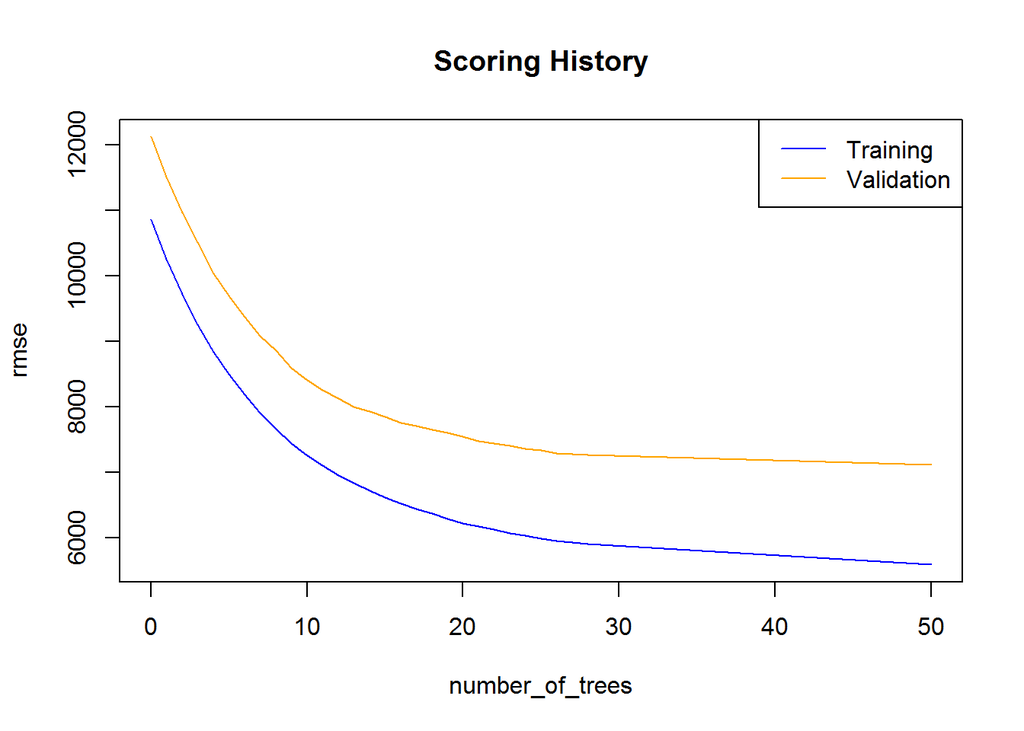

```r
plot(GBM1)
```

3, Neural networks

```r
NN1<-h2o.deeplearning(x=colnames(dx_train)[-2],y="price",training_frame = dx_train,validation_frame = dx_valid)
```

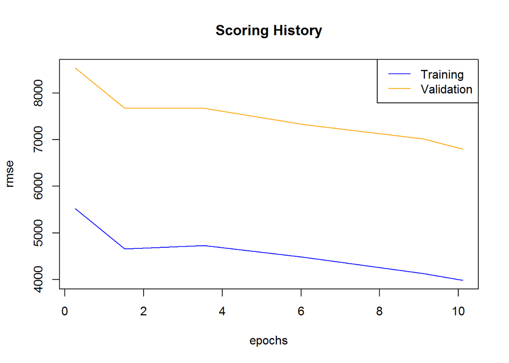

```r
plot(NN1)
```

```r
NN1
```

```
## Model Details:
## ==============
##
## H2ORegressionModel: deeplearning
## Model ID:  DeepLearning_model_R_1489177403592_33
## Status of Neuron Layers: predicting price, regression, gaussian distribution, Quadratic loss, 68Â 401 weights/biases, 810,6 KB, 773Â 068 training samples, mini-batch size 1
##   layer units      type dropout       l1       l2 mean_rate rate_rms
## 1     1   139     Input  0.00 %
## 2     2   200 Rectifier  0.00 % 0.000000 0.000000  0.072582 0.242798
## 3     3   200 Rectifier  0.00 % 0.000000 0.000000  0.121571 0.224793
## 4     4     1    Linear         0.000000 0.000000  0.001278 0.002118
##   momentum mean_weight weight_rms mean_bias bias_rms
## 1
## 2 0.000000   -0.007503   0.101675  0.399079 0.424707
## 3 0.000000   -0.000645   0.095394  0.957292 0.082543
## 4 0.000000    0.033239   0.077711  0.031390 0.000000
##
##
## H2ORegressionMetrics: deeplearning
## ** Reported on training data. **
## ** Metrics reported on temporary training frame with 10124 samples **
##
## MSE:  15839212
## RMSE:  3979.851
## MAE:  1573.994
## RMSLE:  NaN
## Mean Residual Deviance :  15839212
##
##
## H2ORegressionMetrics: deeplearning
## ** Reported on validation data. **
## ** Metrics reported on full validation frame **
##
## MSE:  46182674
## RMSE:  6795.784
## MAE:  1688.704
## RMSLE:  NaN
## Mean Residual Deviance :  46182674
```